# Ejemplo: procesamiento para producir rúbrica

## Preprocesamiento para rúbrica

```r
library(tidyverse)
library(recipes)
library(themis)
library(rsample)
library(parsnip)
library(yardstick)
library(workflows)
library(tune)
library(knitr)
library(patchwork)
```

```r
adult_train <- read_csv("adult.csv", col_names = FALSE)
adult_test <- read_csv("adult_test.csv", col_names = FALSE, comment = ".")
```

```r
preprocesar <- function(adult){
  colnames(adult) <- c('edad', 'tipo_trabajo', 'pond', 'educacion',
                     'educacion_num', 'estado_civil', 'ocupacion', 'relacion', 'info_racial', 'sexo',
                     'ganancias_capital', 'perdidas_capital', 'horas_por_semana', 'pais_origen',
                     'ingreso')
  adulto <- adult %>%
    mutate(pais_origen = ifelse(pais_origen == "?", "Desconocido", pais_origen)) %>%
    mutate(ocupacion = ifelse(ocupacion == "?", "Desconocido", ocupacion)) %>%
    mutate(ingreso = fct_recode(ingreso, bajo = "<=50K", alto = ">50K")) %>%
    mutate(tipo_trabajo = ifelse(tipo_trabajo == "?", "Desconocido", tipo_trabajo)) %>%
    mutate(bajo_auto = ifelse(str_detect(tipo_trabajo, "Self") & (ingreso == "bajo"), "bajo_auto", "otro")) %>%
    mutate(bajo_auto = as.factor(bajo_auto)) %>%
    select(-educacion, -pond, -ingreso)
  adulto
}
adulto_entrena <- preprocesar(adult_train)
adulto_prueba <- preprocesar(adult_test)
```

```r
adulto_entrena
```

| edad | tipo_trabajo | educacion_num | estado_civil | ocupacion | relacion | info_racial | sexo | ganancias_capital | perdidas_capital | horas_por_semana | pais_origen | bajo_auto |
| --- | --- | --- | --- | --- | --- | --- | --- | --- | --- | --- | --- | --- |
| 39 | State-gov | 13 | Never-married | Adm-clerical | Not-in-family | White | Male | 2174 | 0 | 40 | United-States | otro |
| 50 | Self-emp-not-inc | 13 | Married-civ-spouse | Exec-managerial | Husband | White | Male | 0 | 0 | 13 | United-States | bajo_auto |
| 38 | Private | 9 | Divorced | Handlers-cleaners | Not-in-family | White | Male | 0 | 0 | 40 | United-States | otro |
| 53 | Private | 7 | Married-civ-spouse | Handlers-cleaners | Husband | Black | Male | 0 | 0 | 40 | United-States | otro |
| 28 | Private | 13 | Married-civ-spouse | Prof-specialty | Wife | Black | Female | 0 | 0 | 40 | Cuba | otro |
| 37 | Private | 14 | Married-civ-spouse | Exec-managerial | Wife | White | Female | 0 | 0 | 40 | United-States | otro |
| 49 | Private | 5 | Married-spouse-absent | Other-service | Not-in-family | Black | Female | 0 | 0 | 16 | Jamaica | otro |
| 52 | Self-emp-not-inc | 9 | Married-civ-spouse | Exec-managerial | Husband | White | Male | 0 | 0 | 45 | United-States | otro |
| 31 | Private | 14 | Never-married | Prof-specialty | Not-in-family | White | Female | 14084 | 0 | 50 | United-States | otro |
| 42 | Private | 13 | Married-civ-spouse | Exec-managerial | Husband | White | Male | 5178 | 0 | 40 | United-States | otro |

[output cut: 990 more lines]

```r
adulto_entrena %>% group_by(bajo_auto) %>%
  summarise(conteo = n())
```

| bajo_auto | conteo |
| --- | --- |
| bajo_auto | 2311 |
| otro | 30250 |

### Modelo

```r
entrena <- adulto_entrena
prueba <- adulto_prueba
```

```r
receta_adulto <- recipe(bajo_auto ~  educacion_num + info_racial + sexo +
                          horas_por_semana + estado_civil , data = entrena) %>%
  prep()
entrena_prep <- juice(receta_adulto)
```

```r
bosque_1 <-
  rand_forest(trees = 500, mtry = 2, mode = "classification") %>%
  set_engine("ranger") %>%
  fit(bajo_auto ~ . , data = entrena_prep)
```

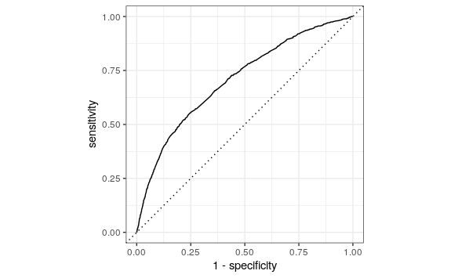

```r
#bosque_1 %>%
#  predict(prueba) %>%
#  bind_cols(prueba) %>%
#  class_metrics(truth = bajo_auto, estimate=.pred_class) %>%
#  kable()
predictions_prob <- bosque_1 %>%
  predict(new_data = prueba, type = "prob") %>%
  bind_cols(prueba %>% select(bajo_auto)) %>%
  select(.pred_bajo_auto, bajo_auto)
datos_roc <- roc_curve(predictions_prob, bajo_auto, .pred_bajo_auto)
autoplot(datos_roc)
```

```r
predictions_prob <- predictions_prob %>%
  mutate(sexo = prueba$sexo, info_racial = prueba$info_racial) %>%
  mutate(info_racial = as.character(info_racial)) %>%
  mutate(info_racial =
    fct_recode(info_racial, Other = "Amer-Indian-Eskimo", Other = "Other")) %>%
  mutate(info_racial = as.character(info_racial))
# bootstrap
boot_metricas <- function(predictions_prob, i){
  preds_boot <- sample_frac(predictions_prob %>% group_by(sexo, info_racial), replace = T) %>%
    ungroup
  roc_total <- roc_auc(preds_boot, bajo_auto, .pred_bajo_auto) %>%
    mutate(grupo = "Total", atributo = "Total")
  log_perdida_total <- mn_log_loss(preds_boot, bajo_auto, .pred_bajo_auto)
  roc_grupos <- roc_auc(preds_boot %>% group_by(sexo), bajo_auto, .pred_bajo_auto) %>%
    rename(grupo = sexo) %>% mutate(atributo = "género")
  log_perdida_grupos <- mn_log_loss(preds_boot %>% group_by(sexo), bajo_auto, .pred_bajo_auto)
  roc_grupos_2 <- roc_auc(preds_boot %>% group_by(info_racial), bajo_auto, .pred_bajo_auto) %>%
    rename(grupo = info_racial) %>% mutate(atributo = "racial")
  log_perdida_grupos_2 <- mn_log_loss(preds_boot %>% group_by(info_racial), bajo_auto, .pred_bajo_auto)
  resumen <- bind_rows(roc_total, roc_grupos, roc_grupos_2)
  resumen$id <- i
  resumen
}
set.seed(2321)
sim_metricas <- map(1:100, ~ boot_metricas(predictions_prob, .x)) %>%
  bind_rows
resumen <- sim_metricas %>% group_by(.metric, .estimator, grupo, atributo) %>%
  summarise(estimador = mean(.estimate), ee = sd(.estimate)/sqrt(length(.estimate))) %>%
  select(-.estimator) %>% ungroup
```

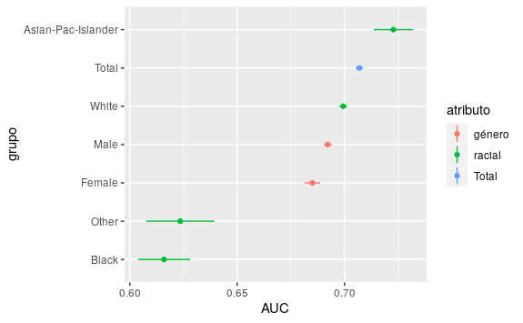

```r
ggplot(resumen %>% mutate(grupo = fct_reorder(grupo, estimador)), aes(x = grupo, y = estimador,
  ymin = estimador - 2*ee, ymax = estimador + 2*ee, colour = atributo)) +
  geom_point() + geom_linerange() + coord_flip() +
  ylab("AUC")
```

Como medidas de equidad utilizaremos la igualdad de oportunidad (equilibrar probablidad de estar en el grupo de interés dentro de cada grupo protegido), o misma tasa de positivos verdaderos.

```r
resultado_cortes <- function(tbl_datos, cortes){
  resultado <- tbl_datos %>%
    left_join(cortes, by = c("sexo", "info_racial")) %>%
    mutate(recibe = .pred_bajo_auto > corte)
  resultado %>% group_by(info_racial, sexo, recibe, bajo_auto, prop_total) %>% count() %>%
    ungroup()
}
```

```r
calcular_cortes_oportunidad <- function(tbl_datos, prop){
  tbl_datos %>%
    filter(bajo_auto=="bajo_auto") %>%
    group_by(info_racial, sexo) %>%
    mutate(rank_p = rank(.pred_bajo_auto) / length(.pred_bajo_auto) ) %>%
    filter(rank_p < prop) %>%
    top_n(1, rank_p) %>%
    unique() %>%
    select(info_racial, sexo, corte = .pred_bajo_auto) %>%
    mutate(prop_total = prop)
}
cortes_op <-
  map(seq(0.01, 1, 0.01), ~ calcular_cortes_oportunidad(predictions_prob, .x))
cortes_op[[10]]
```

| info_racial | sexo | corte | prop_total |
| --- | --- | --- | --- |
| White | Female | 0.020262169 | 0.1 |
| White | Male | 0.046932551 | 0.1 |
| Black | Male | 0.005972597 | 0.1 |
| Asian-Pac-Islander | Male | 0.031118491 | 0.1 |
| Black | Female | 0.003424111 | 0.1 |

```r
resultados_conteo <- map(cortes_op, ~ resultado_cortes(predictions_prob, .x)) %>%
  bind_rows()
```

```r
resumen_tvp <- resultados_conteo %>%
  filter(bajo_auto == "bajo_auto") %>%
  group_by(info_racial, sexo, prop_total) %>%
  mutate(tvp = n / sum(n), total = sum(n)) %>%
  filter(recibe == TRUE) %>%
  mutate(ee = sqrt(tvp * (1-tvp) / total ))
resumen_tvp
```

| info_racial | sexo | recibe | bajo_auto | prop_total | n | tvp | total | ee |
| --- | --- | --- | --- | --- | --- | --- | --- | --- |
| White | Male | TRUE | bajo_auto | 0.01 | 919 | 0.990301724 | 928 | 0.003217044 |
| White | Female | TRUE | bajo_auto | 0.02 | 211 | 0.981395349 | 215 | 0.009215386 |
| White | Male | TRUE | bajo_auto | 0.02 | 910 | 0.980603448 | 928 | 0.004527255 |
| White | Female | TRUE | bajo_auto | 0.03 | 209 | 0.972093023 | 215 | 0.011232879 |
| White | Male | TRUE | bajo_auto | 0.03 | 901 | 0.970905172 | 928 | 0.005517246 |
| Black | Male | TRUE | bajo_auto | 0.04 | 30 | 0.967741935 | 31 | 0.031733508 |
| White | Female | TRUE | bajo_auto | 0.04 | 205 | 0.953488372 | 215 | 0.014362143 |
| White | Male | TRUE | bajo_auto | 0.04 | 898 | 0.967672414 | 928 | 0.005805997 |
| Asian-Pac-Islander | Male | TRUE | bajo_auto | 0.05 | 21 | 0.954545455 | 22 | 0.044409474 |
| Black | Male | TRUE | bajo_auto | 0.05 | 30 | 0.967741935 | 31 | 0.031733508 |

[output cut: 730 more lines]

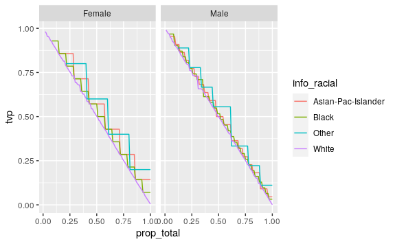

```r
ggplot(resumen_tvp, aes(x = prop_total, y = tvp, colour = info_racial,
                        group = info_racial)) +
  geom_line() + facet_wrap(~sexo)
```

Las tasas de verdaderos positivos son consistentes, como se puede comprobar examinando algunas de ellas. Por ejemplo, si queremos una tasa de positivos correctos el alrededor del 75%,

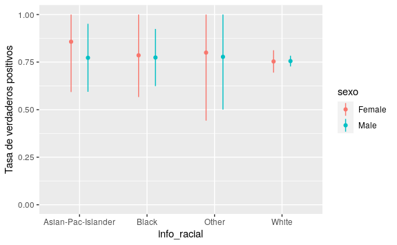

```r
ggplot(resumen_tvp %>% filter(prop_total == 0.25),
  aes(x = info_racial, y = tvp,
      ymin = pmax(0, tvp - 2*ee), ymax = pmin(1, tvp + 2*ee), colour = sexo)) +
  geom_point(position = position_dodge(width = 0.5)) +
  geom_linerange(position = position_dodge(width = 0.5)) +
  ylab("Tasa de verdaderos positivos") + ylim(c(0,1))
```

Y las tasas de verdaderos positivos son consistentes. Para el punto de corte seleccionado

```r
resumen_tvp %>% filter(prop_total == 0.25) %>% select()
```

| info_racial | sexo | prop_total |
| --- | --- | --- |
| Asian-Pac-Islander | Female | 0.25 |
| Asian-Pac-Islander | Male | 0.25 |
| Black | Female | 0.25 |
| Black | Male | 0.25 |
| Other | Female | 0.25 |
| Other | Male | 0.25 |
| White | Female | 0.25 |
| White | Male | 0.25 |

```r
# seleccionar cortes finales según analisis costo-beneficio
cortes_finales <- cortes_op[[60]]
cortes_finales
```

| info_racial | sexo | corte | prop_total |
| --- | --- | --- | --- |
| White | Male | 0.14741805 | 0.6 |
| Other | Male | 0.03906299 | 0.6 |
| Other | Female | 0.03724043 | 0.6 |
| Black | Female | 0.01275133 | 0.6 |
| Asian-Pac-Islander | Male | 0.08734940 | 0.6 |
| Black | Male | 0.03774794 | 0.6 |
| White | Female | 0.05603411 | 0.6 |
| Asian-Pac-Islander | Female | 0.06760193 | 0.6 |

```r
costos_mat <- tibble(bajo_auto = c("bajo_auto", "bajo_auto", "otro", "otro"),
                 califica = c(TRUE, FALSE, TRUE, FALSE),
                 beneficio = c(60000 - 20000, 0, -2000, 0) - 1000)
costos <- predictions_prob %>%
  left_join(cortes_finales) %>%
  mutate(corte = ifelse(is.na(corte), 0.063, corte)) %>% # corte White Male
  mutate(califica = .pred_bajo_auto > corte) %>%
  group_by(bajo_auto, califica) %>%
  summarise(n = n()) %>% left_join(costos_mat)
costos <- costos %>% mutate(total = n * beneficio) %>%
  ungroup %>%
  left_join(predictions_prob %>% group_by(bajo_auto) %>% summarise(pob = n())) %>%
  filter(califica == TRUE) %>%
  mutate(cobertura = n / pob)
costos
```

| bajo_auto | califica | n | beneficio | total | pob | cobertura |
| --- | --- | --- | --- | --- | --- | --- |
| bajo_auto | TRUE | 500 | 39000 | 19500000 | 1231 | 0.4061738 |
| otro | TRUE | 2686 | -3000 | -8058000 | 15050 | 0.1784718 |

## Rubrica

### 1. Información básica

- Personas que desarrollaron el modelo, fecha, versión, tipo
- Algoritmos que se usaron para entrenar, parámetros supuestos o restricciones
- Antecedentes

Modelo de predicción de ingresos bajos para personas autoempleadas versión 0.1, 22 July, 2020, construido por LFG.

Se utilizó un bosque aleatorio construido con *ranger* 0.12.1 de R. Modelos para predecir la categoría de ingreso y estatus de autoempleo basados en datos similares con los se han construido en varias ocasiones con diversos propósitos. En este caso particular los datos utilizados son un ejemplo común para ilustrar métodos de aprendizaje automático y equidad de predicciones (ver por ejemplo (Kohavi 1997)).

### 2. Casos de uso

- Casos de uso considerados durante el desarrollo
- Población objetivo y horizonte de predicciones
- Actores y componentes que interactuarán con los resultados
- Usos no considerados y advertencias relacionadas

El modelo predictivo de ingreso tiene como fin indentificar personas autoempleadas de ingresos bajos con el fin de seleccionarlos como candidatos para un programa de mejora en sus condiciones de trabajo. Este modelo será utilizado en complemento de encuestas operadas por terceros, que tendrán disponible una predicción de identificar con menor costo personas autoempleadas de ingresos bajos.

La población objetivo es el total de la población de EUA (1994) mayor a 16 años y empleados en algún trabajo (mínimo de 1 hora a la semana) con una remuneración mínima de 100 dólares anuales. Buscamos hacer predicciones en 1994-1995

El modelo será utilizado después de que un tercero levante encuestas en zonas de interés para producir un *scoring* de probabilidades de autoempleo de ingreso bajo. Los operadores del programa decidirán entonces, dependiendo de presupuesto y alcances, qué personas entrevistadas en esa encuesta se integrarán al programa.

### 3. Métricas de desempeño

- Métricas técnicas usadas para seleccionar y evaluar modelos
- Análisis costo-beneficio del modelo para su caso de uso según (2)
- Definición de grupos protegidos y medidas de equidad seleccionadas

Las métricas usadas para la selección de modelos fue el AUC, que considera las probablidades de estar en la categoría de autoempleo con bajos ingresos. Consideramos como atributos protegidos *sexo* e *info_racial*, y buscamos equidad de oportunidad (igualar tasas de aceptación entre aquellos que califican al programa).

### 4. Datos de validación

- Conjuntos de datos usados y su etiquetado
- Pasos de preprocesamiento
- Evaluación de adaptación de datos de validación según el caso de uso (2)

Los datos utilizados para seleccionar y evaluar el modelo fueron extraidos aleatoriamente (mismas probabilidades) de los datos del censo de Estados Unidos (1994, agregar referencia). Se descartaron 6 registros con datos inconsistentes (valores fuera de rango).

En total se escogieron 16281 casos para la evaluación, y alrededor del 7.6% están en la categoria de autoempleo con ingresos bajos.

En el preprocesamiento se codificaron los valores faltantes de variables categóricas con “Desconocido”- El ingreso reportado se cortó en más de 50 mil y menos de 50 mil dólares al año. La variable de autoempleo fue extraída directamente de los datos reportados en el censo.

**No se utilizaron los ponderadores de la muestra de evaluación**. Estos ponderadores están basados en sexo, edad, estado y raza. Sin embargo, reportamos errores individuales para sexo y raza.

### 5. Datos de entrenamiento

- Conjunto de datos usados y su etiquetado
- Pasos de preprocesamiento
- Sesgos y deficiencias potenciales según el caso de uso (2)

El mismo proceso se utilizó para los datos de entrenamiento, con un total de 32561 casos y 7.1% con autoempleo de ingresos bajos.

### 6. Resumen de análisis cuantitativo

- Error de validación reportado
- Resumen de análisis costo-beneficio
- Reporte de medidas de equidad para grupos protegidos

El auc del modelo seleccionado, en el conjunto de prueba y sin ecualización de oportunidad, fue de

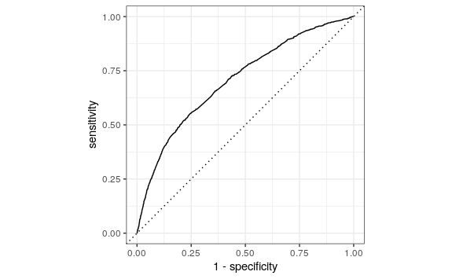

```r
autoplot(datos_roc)
```

Aunque encontramos diferencias importantes en el desempeño dependiendo de atributos protegidos:

```r
resumen %>% knitr::kable(digits = 3)
```

| .estimator | .metric | grupo | atributo | estimador | ee |
| --- | --- | --- | --- | --- | --- |
| binary | roc_auc | Asian-Pac-Islander | racial | 0.723 | 0.005 |
| binary | roc_auc | Black | racial | 0.616 | 0.006 |
| binary | roc_auc | Female | género | 0.685 | 0.002 |
| binary | roc_auc | Male | género | 0.692 | 0.001 |
| binary | roc_auc | Other | racial | 0.623 | 0.008 |
| binary | roc_auc | Total | Total | 0.707 | 0.001 |
| binary | roc_auc | White | racial | 0.699 | 0.001 |

Las tasas de verdaderos positivos para grupos protegidos son consistentes:

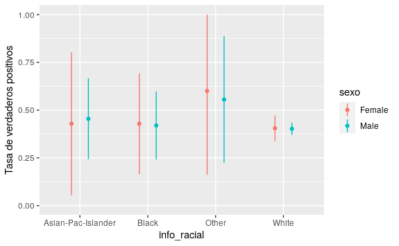

```r
ggplot(resumen_tvp %>% filter(prop_total == 0.6),
  aes(x = info_racial, y = tvp,
      ymin = pmax(0, tvp - 2*ee), ymax = pmin(1, tvp + 2*ee), colour = sexo)) +
  geom_point(position = position_dodge(width = 0.5)) +
  geom_linerange(position = position_dodge(width = 0.5)) +
  ylab("Tasa de verdaderos positivos") + ylim(c(0,1))
```

En cuanto al costo beneficio, utilizamos los puntos de corte

```r
cortes_finales %>% select(-prop_total)
```

| info_racial | sexo | corte |
| --- | --- | --- |
| White | Male | 0.14741805 |
| Other | Male | 0.03906299 |
| Other | Female | 0.03724043 |
| Black | Female | 0.01275133 |
| Asian-Pac-Islander | Male | 0.08734940 |
| Black | Male | 0.03774794 |
| White | Female | 0.05603411 |
| Asian-Pac-Islander | Female | 0.06760193 |

```r
costos
```

| bajo_auto | califica | n | beneficio | total | pob | cobertura |
| --- | --- | --- | --- | --- | --- | --- |
| bajo_auto | TRUE | 500 | 39000 | 19500000 | 1231 | 0.4061738 |
| otro | TRUE | 2686 | -3000 | -8058000 | 15050 | 0.1784718 |

Y el beneficio total por beneficiario del programa es de:

```r
costos %>%
  summarise(beneficio_total = sum(total) / first(n))
```

| beneficio_total |
| --- |
| 22884 |

### 7. Recomendaciones de monitoreo

- Estrategia de monitoreo y mejora en producción
- Estrategias de monitoreo humano de predicciones (si aplica)

Monitorear la tasa de personas que califica (positivos) en el tiempo, pues cambios en inflación e ingreso en el tiempo pueden requerir ajuste de puntos de corte.

Considerar sobremuestras en los datos de grupos minoritarios, que puede dar más certidumbre acerca de la equidad de oportunidad en las predicciones.

### 8. (Opcional) Explicabilidad de predicciones

Valores de Shapley serán usados si los beneficiarios requieren explicación del estado de solicitud. Es posible incluir la revisión humana para aceptar una solicitud, pero **deberá ser contabilizado en los costos**.

# References

Kohavi, Ron. 1997. “Scaling up the Accuracy of Naive-Bayes Classifiers: A Decision-Tree Hybrid.” *KDD*, September.